# 6: Analysis of longitudinal data

Summary graph:

```r
# Number of subjects (per group):
n <- 16

# Summary data with mean and standard error of bprs by treatment and week
RATSLS <- RATSL %>%
  group_by(Group, Time) %>%
  summarise(mean = mean(Weight), se = sd(Weight) ) %>%
  ungroup()
# Glimpse the data
glimpse(RATSLS)
```

```
## Rows: 33
## Columns: 4
## $ Group <fct> 1, 1, 1, 1, 1, 1, 1, 1, 1, 1, 1, 2, 2, 2, 2, 2, 2, 2, 2, 2, 2, 2…
## $ Time  <dbl> 1, 8, 15, 22, 29, 36, 43, 44, 50, 57, 64, 1, 8, 15, 22, 29, 36, …
## $ mean  <dbl> 250.625, 255.000, 254.375, 261.875, 264.625, 265.000, 267.375, 2…
## $ se    <dbl> 15.22158, 13.09307, 11.47591, 13.60081, 11.05748, 11.78377, 10.9…
```

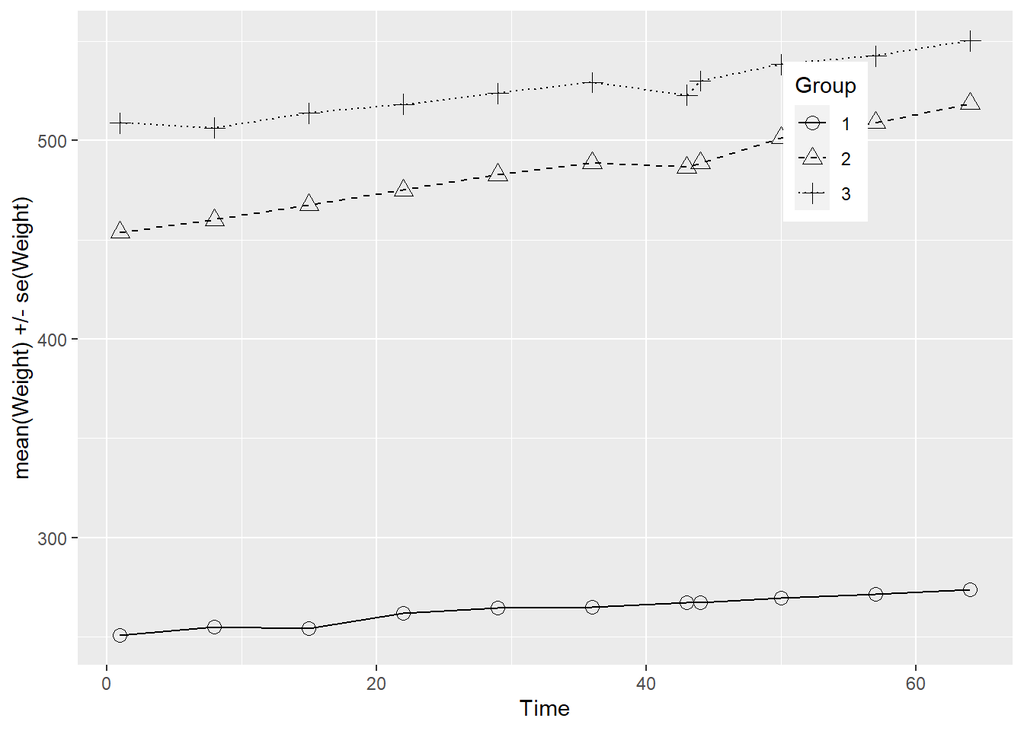

```r
# Plot the mean profiles
ggplot(RATSLS, aes(x = Time, y = mean, linetype = Group, shape = Group)) +
  geom_line() +
  scale_linetype_manual(values = c(1,2,3)) +
  geom_point(size=3) +
  scale_shape_manual(values = c(1,2,3)) +
  #geom_errorbar(aes(ymin=mean-se, ymax=mean+se, linetype="1"), width=0.3) +
  theme(legend.position = c(0.8,0.8)) +
  scale_y_continuous(name = "mean(Weight) +/- se(Weight)")
```

The summary graph visualizes the differences between th groups. Here, we can see that groups 2 and 3 are at a similar level, whereas group 1 is much lower.

Find outliers and remove them:

```r
# Create a summary data by treatment and subject with mean as the summary variable (ignoring baseline week 1)
RATSL8S <- RATSL %>%
  filter(Time > 1) %>%
  group_by(Group, ID) %>%
  summarise(mean=mean(Weight) ) %>%
  ungroup()
# Glimpse the data
glimpse(RATSL8S)
```

```
## Rows: 16
## Columns: 3
## $ Group <fct> 1, 1, 1, 1, 1, 1, 1, 1, 2, 2, 2, 2, 3, 3, 3, 3
## $ ID    <fct> 1, 2, 3, 4, 5, 6, 7, 8, 9, 10, 11, 12, 13, 14, 15, 16
## $ mean  <dbl> 263.2, 238.9, 261.7, 267.2, 270.9, 276.2, 274.6, 267.5, 443.9, 4…
```

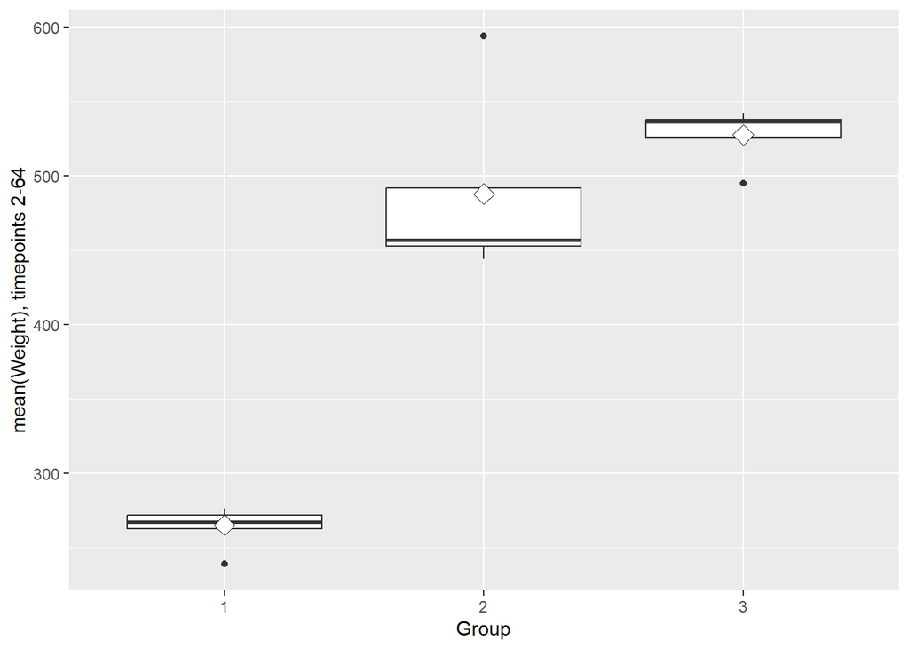

```r
# Draw a boxplot of the mean versus treatment
ggplot(RATSL8S, aes(x = Group, y = mean)) +
  geom_boxplot() +
  stat_summary(fun = "mean", geom = "point", shape=23, size=4, fill = "white") +
  scale_y_continuous(name = "mean(Weight), timepoints 2-64")
```

```r
# Create a new data by filtering the outlier and adjust the ggplot code the draw the plot again with the new data
RATSL8S1 <- RATSL8S %>% filter(mean < 550) # 550 chosen based on the plot above
```

A test for difference between the groups:

```r
# We use the data without the outlier

# the original data is also meeded
RATS <- read.table("https://raw.githubusercontent.com/KimmoVehkalahti/MABS/master/Examples/data/rats.txt", header = TRUE, sep = '\t')

# Perform a two-sample t-test
# t.test(mean ~ Group, data = RATSL8S1, var.equal = TRUE)
# the t-test needs exactly 2 levels but we have 3
# -> let's test level 1 vs. (level 2 and 3)
# -> make a new grouping variable for this
RATSL8S1$Group_2 <- rep(NA, nrow(RATSL8S1))
RATSL8S1$Group_2[RATSL8S1$Group == 1] <- 1
RATSL8S1$Group_2[RATSL8S1$Group == 2 | RATSL8S1$Group == 3] <- 2
RATSL8S1$Group_2 <- as.factor(RATSL8S1$Group_2)
t.test(mean ~ Group_2, data = RATSL8S1, var.equal = TRUE)
```

```
##
##  Two Sample t-test
##
## data:  mean by Group_2
## t = -14.554, df = 13, p-value = 2.002e-09
## alternative hypothesis: true difference in means between group 1 and group 2 is not equal to 0
## 95 percent confidence interval:
##  -264.4733 -196.1053
## sample estimates:
## mean in group 1 mean in group 2
##        265.0250        495.3143
```

```r
# Add the baseline from the original data as a new variable to the summary data
RATSL8S2 <- RATSL8S %>% mutate(baseline = RATS$WD1)


# anova for all 3 groups
# Fit the linear model with the mean as the response
fit <- lm(mean ~ Group + baseline, data = RATSL8S2)
# Compute the analysis of variance table for the fitted model with anova()
anova(fit)
```

```
## Analysis of Variance Table
##
## Response: mean
##           Df Sum Sq Mean Sq F value    Pr(>F)
## Group      2 238620  119310  874.89 9.986e-14 ***
## baseline   1  15884   15884  116.48 1.562e-07 ***
## Residuals 12   1636     136
## ---
## Signif. codes:  0 '***' 0.001 '**' 0.01 '*' 0.05 '.' 0.1 ' ' 1
```

```r
# anova for the new grouping variable
RATSL8S2$Group_2 <- rep(NA, nrow(RATSL8S2))
RATSL8S2$Group_2[RATSL8S2$Group == 1] <- 1
RATSL8S2$Group_2[RATSL8S2$Group == 2 | RATSL8S2$Group == 3] <- 2
RATSL8S2$Group_2 <- as.factor(RATSL8S2$Group_2)
# Fit the linear model with the mean as the response
fit <- lm(mean ~ Group_2 + baseline, data = RATSL8S2)
# Compute the analysis of variance table for the fitted model with anova()
anova(fit)
```

```
## Analysis of Variance Table
##
## Response: mean
##           Df Sum Sq Mean Sq F value    Pr(>F)
## Group_2    1 235468  235468 1677.25 3.954e-15 ***
## baseline   1  18848   18848  134.26 3.178e-08 ***
## Residuals 13   1825     140
## ---
## Signif. codes:  0 '***' 0.001 '**' 0.01 '*' 0.05 '.' 0.1 ' ' 1
```

The t-test has a small p-value indicating a statistically significant difference between the group 1 and combined groups 2 and 3.

The first anova test compares group 1 vs. group 2 vs. group 3. There the baseline and the grouping variable are both significant, so there seems to be a difference between the groups.

The second anova test compares group 1 vs. (group 2 vs. group 3), just like we had in the t-test. THere both the baseline and the grouping variable are significant, indicating a difference between the groups.

### R codes of Exercise Set 6: Meet and Repeat: PART II, using the BPRS data

Read in data:

```r
BPRSL <- read_csv("./data/BPRSL.csv")
BPRSL$treatment <- factor(BPRSL$treatment)
BPRSL$subject <- factor(BPRSL$subject)
```

Plot the data ignoring the longitudinal nature of it:

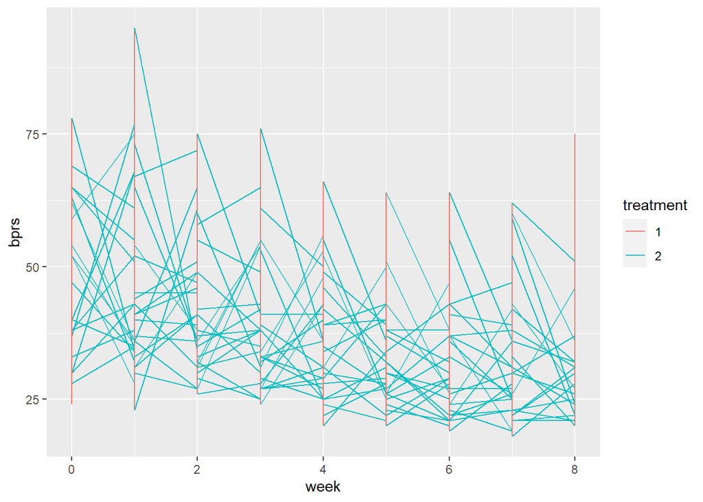

```r
# # this copied directly from the exercises, gives an error for the linetype = treatment
# ggplot(BPRSL, aes(x = week, y = bprs, group = subject)) +
#   geom_line(aes(linetype = treatment)) +
#   scale_x_continuous(name = "Time ", breaks = seq(0, 60, 10)) +
#   scale_y_continuous(name = "bprs") +
#   theme(legend.position = "top")
# # `geom_line()` can't have varying colour, linewidth, and/or alpha
# #   along the line when linetype isn't solid
#
#
# # in the exercises when we were plotting BPRSL, the linetype was in the plot initiation aestetics, moving it there now
# ggplot(BPRSL, aes(x = week, y = bprs, group = subject, linetype = treatment)) +
#   geom_line() +
#   scale_x_continuous(name = "Time ", breaks = seq(0, 60, 10)) +
#   scale_y_continuous(name = "bprs") +
#   theme(legend.position = "top")
# # this looks weird
# # giving an error when plotting this on another day??
#
# # the columns are kinda the same type of data in BPRSL and RATSL
# # modify the rest to be the exact same
# BPRSL$bprs <- as.integer(BPRSL$bprs)
# BPRSL$week <- as.integer(BPRSL$week)
#
# ggplot(BPRSL, aes(x = week, y = bprs, group = subject)) +
#   geom_line(aes(linetype = treatment)) +
#   scale_x_continuous(name = "Time ", breaks = seq(0, 60, 10)) +
#   scale_y_continuous(name = "bprs") +
#   theme(legend.position = "top")
# # still the same error
#
# # repeat the same preprocessing for the data here as for the RATS in the exercises:
# BPRS <- read.table("https://raw.githubusercontent.com/KimmoVehkalahti/MABS/master/Examples/data/BPRS.txt", sep =" ", header = T)
# BPRS$treatment <- factor(BPRS$treatment)
# BPRS$subject <- factor(BPRS$subject)
# BPRSL <- pivot_longer(BPRS, cols=-c(subject,treatment), names_to = "weeks",values_to = "bprs")  %>%  mutate(week = as.integer(substr(weeks,5,5))) %>% arrange(week)
#
# ggplot(BPRSL, aes(x = week, y = bprs, group = subject)) +
#   geom_line(aes(linetype = treatment)) +
#   scale_x_continuous(name = "Time (days)", breaks = seq(0, 60, 10)) +
#   scale_y_continuous(name = "Weight (grams)") +
#   theme(legend.position = "top")
# # still an error saying that
# # `geom_line()` can't have varying colour, linewidth, and/or
# #   alpha along the line when linetype isn't solid
#
# # how were we able to run this exact same thing in the exercises, but now get an error??
# # the column data types are the same, the column names are correct
# # the error is weird, why do we get it here but not in the exercises??

# try by changing the original code
ggplot(BPRSL, aes(x = week, color=treatment, group = subject)) +
  geom_line(aes(y=bprs))
```

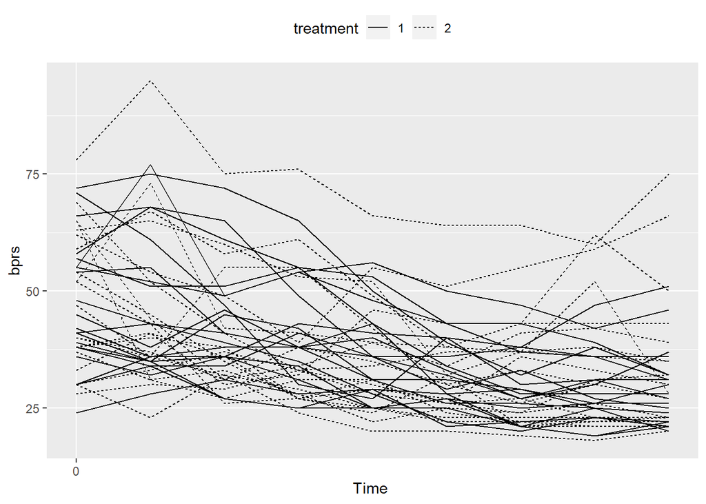

```r
# this does produce a plot with no errors, but it still looks weird

# all subjects are in both groups, that is likely why the plotting does not work
# -> make the 20 individuals be 40, so that one individual is in just one of the two groups, not both
# this data to be used just for plotting now
bprs <- read_csv("./data/BPRSL.csv") %>%
        mutate(subject = factor(subject+(treatment-1)*20)) %>%
        mutate(treatment = factor(treatment))
# the original way to plot
ggplot(bprs, aes(x = week, y = bprs, group = subject)) +
  geom_line(aes(linetype = treatment)) +
  scale_x_continuous(name = "Time ", breaks = seq(0, 60, 10)) +
  scale_y_continuous(name = "bprs") +
  theme(legend.position = "top")
```

A multiple linear regression model ignoring the longitudinal nature of the data:

```r
# create a regression model RATS_reg
BPRS_reg <- lm(bprs ~ week + treatment, data = BPRSL)

# print out a summary of the model
summary(BPRS_reg)
```

```
##
## Call:
## lm(formula = bprs ~ week + treatment, data = BPRSL)
##
## Residuals:
##     Min      1Q  Median      3Q     Max
## -22.454  -8.965  -3.196   7.002  50.244
##
## Coefficients:
##             Estimate Std. Error t value Pr(>|t|)
## (Intercept)  46.4539     1.3670  33.982   <2e-16 ***
## week         -2.2704     0.2524  -8.995   <2e-16 ***
## treatment2    0.5722     1.3034   0.439    0.661
## ---
## Signif. codes:  0 '***' 0.001 '**' 0.01 '*' 0.05 '.' 0.1 ' ' 1
##
## Residual standard error: 12.37 on 357 degrees of freedom
## Multiple R-squared:  0.1851, Adjusted R-squared:  0.1806
## F-statistic: 40.55 on 2 and 357 DF,  p-value: < 2.2e-16
```

In the linear regression, the variable week is statistically significant, as one might expect because as the time progresses, the bprs scores change in all groups.

Random Intercept Model:

This allows the linear regression fit for each individual to differ in intercept from others.

```r
# Create a random intercept model
BPRS_ref <- lmer(bprs ~ week + treatment + (1 | subject), data = BPRSL, REML = FALSE)

# Print the summary of the model
summary(BPRS_ref)
```

```
## Linear mixed model fit by maximum likelihood  ['lmerMod']
## Formula: bprs ~ week + treatment + (1 | subject)
##    Data: BPRSL
##
##      AIC      BIC   logLik deviance df.resid
##   2748.7   2768.1  -1369.4   2738.7      355
##
## Scaled residuals:
##     Min      1Q  Median      3Q     Max
## -3.0481 -0.6749 -0.1361  0.4813  3.4855
##
## Random effects:
##  Groups   Name        Variance Std.Dev.
##  subject  (Intercept)  47.41    6.885
##  Residual             104.21   10.208
## Number of obs: 360, groups:  subject, 20
##
## Fixed effects:
##             Estimate Std. Error t value
## (Intercept)  46.4539     1.9090  24.334
## week         -2.2704     0.2084 -10.896
## treatment2    0.5722     1.0761   0.532
##
## Correlation of Fixed Effects:
##            (Intr) week
## week       -0.437
## treatment2 -0.282  0.000
```

Here the variance for the random effects “subject (Intercept)” is rather big, so there may be an actual difference in the intercepts between subjects.

Random Intercept and Random Slope Model:

This allows the linear regression fits for each individual to differ in intercept but also in slope. This way it is possible to account for the individual differences in the individuals’ bpcr profiles, but also the effect of time.

```r
# create a random intercept and random slope model
BPRS_ref1 <- lmer(bprs ~ week + treatment + (week | subject), data = BPRSL, REML = FALSE)

# print a summary of the model
summary(BPRS_ref1)
```

```
## Linear mixed model fit by maximum likelihood  ['lmerMod']
## Formula: bprs ~ week + treatment + (week | subject)
##    Data: BPRSL
##
##      AIC      BIC   logLik deviance df.resid
##   2745.4   2772.6  -1365.7   2731.4      353
##
## Scaled residuals:
##     Min      1Q  Median      3Q     Max
## -2.8919 -0.6194 -0.0691  0.5531  3.7976
##
## Random effects:
##  Groups   Name        Variance Std.Dev. Corr
##  subject  (Intercept) 64.8222  8.0512
##           week         0.9609  0.9802   -0.51
##  Residual             97.4305  9.8707
## Number of obs: 360, groups:  subject, 20
##
## Fixed effects:
##             Estimate Std. Error t value
## (Intercept)  46.4539     2.1052  22.066
## week         -2.2704     0.2977  -7.626
## treatment2    0.5722     1.0405   0.550
##
## Correlation of Fixed Effects:
##            (Intr) week
## week       -0.582
## treatment2 -0.247  0.000
```

```r
# perform an ANOVA test on the two models
anova(BPRS_ref1, BPRS_ref)
```

```
## Data: BPRSL
## Models:
## BPRS_ref: bprs ~ week + treatment + (1 | subject)
## BPRS_ref1: bprs ~ week + treatment + (week | subject)
##           npar    AIC    BIC  logLik deviance  Chisq Df Pr(>Chisq)
## BPRS_ref     5 2748.7 2768.1 -1369.4   2738.7
## BPRS_ref1    7 2745.4 2772.6 -1365.7   2731.4 7.2721  2    0.02636 *
## ---
## Signif. codes:  0 '***' 0.001 '**' 0.01 '*' 0.05 '.' 0.1 ' ' 1
```

Random Intercept and Random Slope Model with group × time interaction:

```r
# create a random intercept and random slope model with the interaction
BPRS_ref2 <- lmer(bprs ~ week + treatment + week * treatment + (week | subject), data = BPRSL, REML = FALSE)

# print a summary of the model
summary(BPRS_ref2)
```

```
## Linear mixed model fit by maximum likelihood  ['lmerMod']
## Formula: bprs ~ week + treatment + week * treatment + (week | subject)
##    Data: BPRSL
##
##      AIC      BIC   logLik deviance df.resid
##   2744.3   2775.4  -1364.1   2728.3      352
##
## Scaled residuals:
##     Min      1Q  Median      3Q     Max
## -3.0512 -0.6271 -0.0768  0.5288  3.9260
##
## Random effects:
##  Groups   Name        Variance Std.Dev. Corr
##  subject  (Intercept) 64.9964  8.0620
##           week         0.9687  0.9842   -0.51
##  Residual             96.4707  9.8220
## Number of obs: 360, groups:  subject, 20
##
## Fixed effects:
##                 Estimate Std. Error t value
## (Intercept)      47.8856     2.2521  21.262
## week             -2.6283     0.3589  -7.323
## treatment2       -2.2911     1.9090  -1.200
## week:treatment2   0.7158     0.4010   1.785
##
## Correlation of Fixed Effects:
##             (Intr) week   trtmn2
## week        -0.650
## treatment2  -0.424  0.469
## wek:trtmnt2  0.356 -0.559 -0.840
```

```r
# perform an ANOVA test on the two models
anova(BPRS_ref2, BPRS_ref1)
```

```
## Data: BPRSL
## Models:
## BPRS_ref1: bprs ~ week + treatment + (week | subject)
## BPRS_ref2: bprs ~ week + treatment + week * treatment + (week | subject)
##           npar    AIC    BIC  logLik deviance  Chisq Df Pr(>Chisq)
## BPRS_ref1    7 2745.4 2772.6 -1365.7   2731.4
## BPRS_ref2    8 2744.3 2775.4 -1364.1   2728.3 3.1712  1    0.07495 .
## ---
## Signif. codes:  0 '***' 0.001 '**' 0.01 '*' 0.05 '.' 0.1 ' ' 1
```

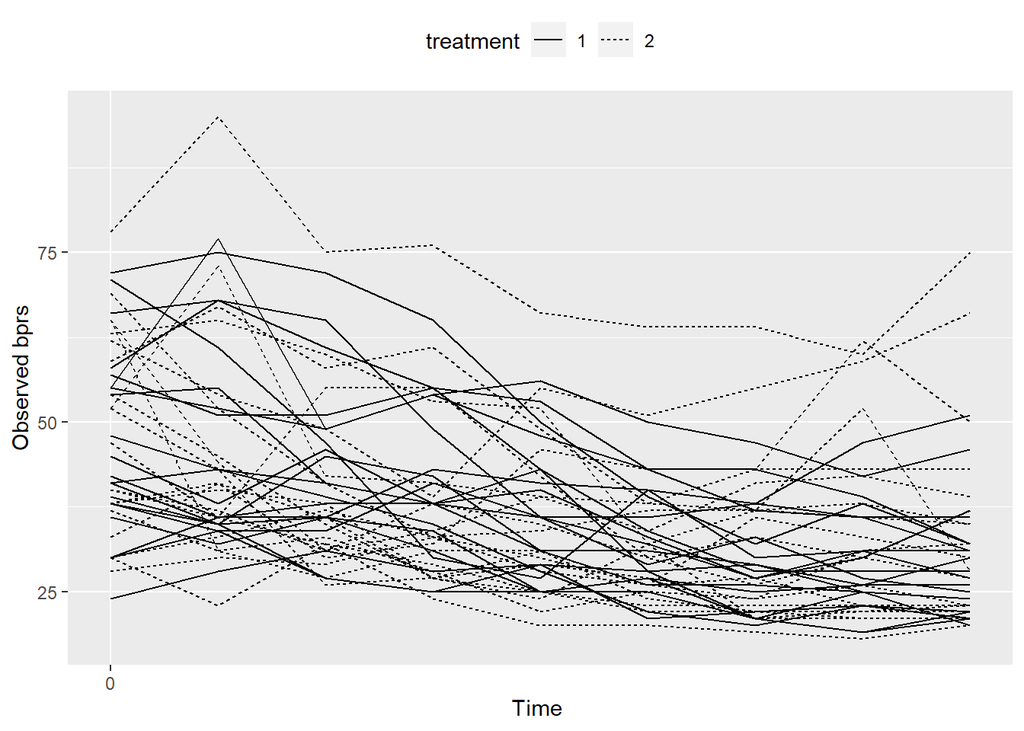

```r
# draw the plot of BPRSL with the observed Weight values
# ggplot(BPRSL, aes(x = week, y = bprs, group = subject)) +
#   geom_line(aes(linetype = treatment)) +
#   scale_x_continuous(name = "Time (days)", breaks = seq(0, 60, 20)) +
#   scale_y_continuous(name = "Observed weight (grams)") +
#   theme(legend.position = "top")
# this still does not work, just like above

# try with the designated plotting data, bprs, made above
ggplot(bprs, aes(x = week, y = bprs, group = subject)) +
  geom_line(aes(linetype = treatment)) +
  scale_x_continuous(name = "Time ", breaks = seq(0, 60, 20)) +
  scale_y_continuous(name = "Observed bprs") +
  theme(legend.position = "top")
```

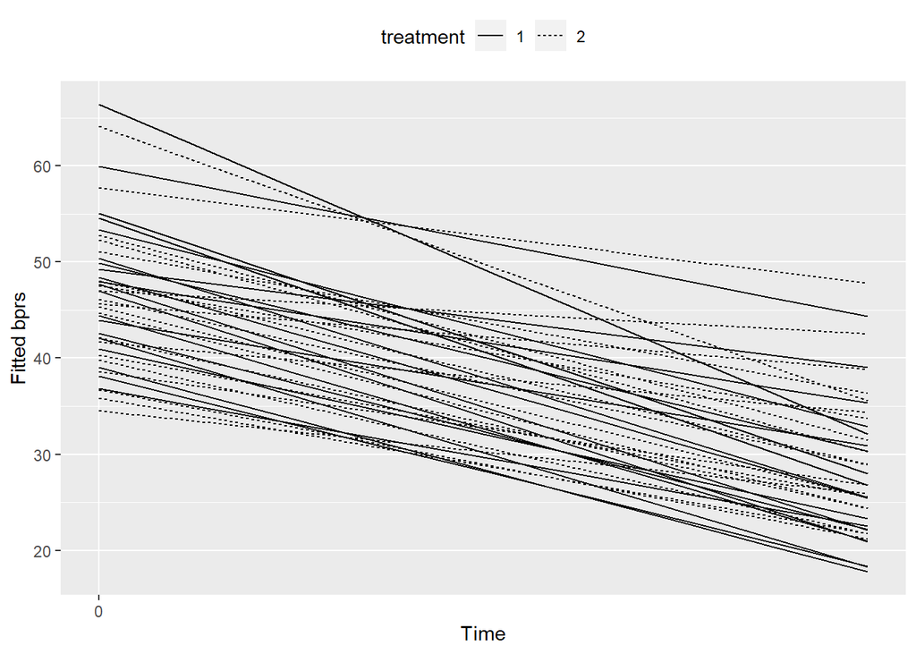

```r
# Create a vector of the fitted values
Fitted <- fitted(BPRS_ref2) # using this interaction model here, even though the interaction did not improve the fit

# Create a new column fitted to RATSL
BPRSL$fitted <- Fitted

# draw the plot of BPRSL with the Fitted values of weight
# ggplot(BPRSL, aes(x = week, y = fitted, group = subject)) +
#   geom_line(aes(linetype = treatment)) +
#   scale_x_continuous(name = "Time (days)", breaks = seq(0, 60, 20)) +
#   scale_y_continuous(name = "Fitted weight (grams)") +
#   theme(legend.position = "top")
# this still does not work, just like above

# try with the designated plotting data, bprs, made above
bprs$fitted <- Fitted
ggplot(bprs, aes(x = week, y = fitted, group = subject)) +
  geom_line(aes(linetype = treatment)) +
  scale_x_continuous(name = "Time", breaks = seq(0, 60, 20)) +
  scale_y_continuous(name = "Fitted bprs") +
  theme(legend.position = "top")
```

Comparing the interaction model to the previous model, the interaction term did not improve the fit significantly. The fitted values do seem similar to the data, and it does look like a radom intercept and a random slope make the plot look nicer.